# s06 — can you filter your way out of reference bias? (chr19, SNP-only)

gwct

10/26/2026 13:04 EDT

```r
knitr::opts_chunk$set(echo = TRUE, warning = FALSE, message = FALSE, fig.align = "center")
library(ggplot2); library(dplyr); library(tidyr); library(readr)
source("analyses/lib/design.r")   # bartheme(), corecol(); knit from the project root
```

**Provenance**

- **Rendered from commit** `761a36dcb53d` (branch `mason2-sims`) on 2026-10-26 13:04
- **This notebook:** notebook as committed
- **Analysis code:** no uncommitted edits under `analyses/`
- Each data file’s producing script and command: the section’s `MANIFEST.yaml`

# 1 Question & design

**Can standard hard filters recover the divergence lost to reference bias — or do they only manage false positives?** A common reflex is to blame low recall on lenient calling and reach for quality/depth/mapping-quality filters. But a filter can only ever *remove* calls, so it can raise precision, never recall. This section makes that concrete, and turns up a sharper point: some filters actively **amplify** reference bias.

- **Data (no new compute).** The **raw single-shot (iteration 1) caller VCFs**, `calls.norm`, homogeneous divergence D ∈ {0.02…0.10}, 30×, seed 42 — the caller output already exists. Each VCF is read once (`bcftools query`) and every threshold is swept in memory (`analyses/s06-filtering/scripts/filter_sweep.py`). **SNP** filtering uses **s01** (SNP-only); **indel** filtering uses **s02** (SNP + indel), scored separately by variant type.
- **Filter axes**, one at a time: **QUAL** (variant quality, column 6); **DP** (per-sample depth, `FMT/DP`); **MQ** (RMS mapping quality — `INFO/MQ` for gatk & bcftools, `INFO/MQM` for freebayes). Keep calls with axis ≥ threshold.
- **Metrics** (per filtered call set): **recall** = hom-alt calls matching a truth 1|1 site / number of truth 1|1 sites (the divergence-recovery / reference-bias axis); **precision** = calls matching any truth SNP site / calls passing the filter. `threshold = 0` is unfiltered, so `recall(0)` is the ceiling and reference bias is `1 − recall(0)`.
- **Single-shot only.** This asks what filtering the caller’s output does; the iterative interaction (filtering *during* iteration) is deferred — it would need re-running iteration.

```r
prep <- function(path) read_csv(path) %>%
  mutate(caller = factor(caller, levels = c("gatk", "bcftools", "freebayes")),
         axis   = factor(axis, levels = c("QUAL", "DP", "MQ")),
         divergence = factor(divergence))
# SNP filtering on s01 (SNP-only); indel filtering on s02 (SNP + indel)
df <- prep("analyses/s06-filtering/results/s06-filter-sweep.csv") %>% filter(vtype == "snp")
di <- prep("analyses/s06-filtering/results/s06-filter-sweep-s02.csv") %>% filter(vtype == "indel")
dcols <- corecol(pal = "wilke", numcol = length(levels(df$divergence)))
```

# 2 Recall is set by divergence, not the filter (SNPs)

Recall of true divergence against each filter threshold. Within a caller, the curves are **stacked by divergence and essentially flat in the filter** — the ceiling is set by how diverged the genome is (reference bias), and no threshold lifts it. The exception is *downward*: past a point, filtering starts deleting real calls.

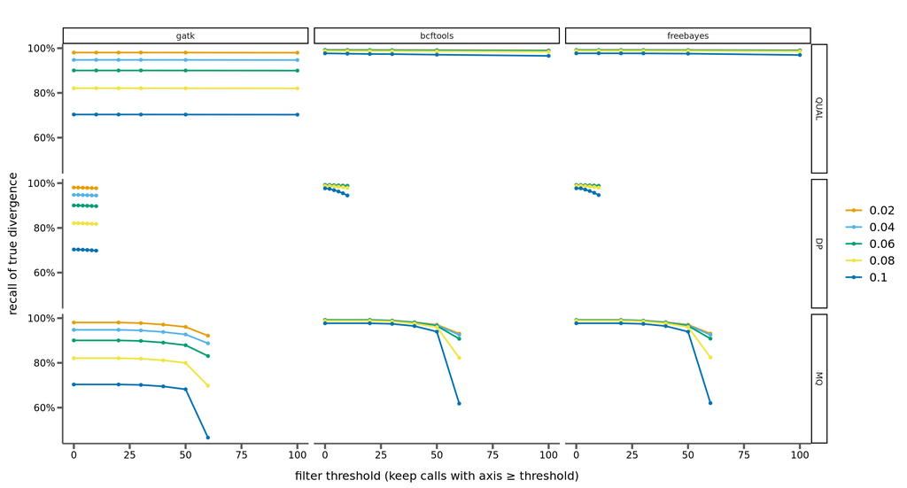

```r
ggplot(df, aes(threshold, recall, color = divergence)) +
  geom_line(linewidth = 0.8) + geom_point(size = 1.2) +
  facet_grid(axis ~ caller, scales = "free_x") +
  scale_color_manual(values = dcols, name = "divergence") +
  scale_y_continuous(labels = scales::percent) +
  labs(x = "filter threshold (keep calls with axis ≥ threshold)", y = "recall of true divergence") +
  bartheme() + theme(legend.position = "right")
```

*Interpretation.*

- **QUAL:** recall is flat across the whole range — the lost variants are **not** low-quality calls sitting in the VCF, they are *absent* (never emitted). gatk is perfectly flat; bcftools/ freebayes lose a point or two only at extreme QUAL.
- **DP:** a mild, steady recall *cost* with no compensating benefit — depth filtering removes real low-coverage calls.
- **MQ — the cautionary one:** at high divergence, an aggressive MQ cut **collapses** recall (freebayes drops from 0.98 to 0.62 at MQ ≥ 60, D = 0.10). This is reference bias *amplified*: the diverged reads legitimately carry **lower** mapping quality (more mismatches), so an MQ filter preferentially deletes exactly the variants we are trying to recover.

# 3 Filtering buys precision — mainly for the over-caller (SNPs)

The same sweep, for precision. Filtering’s real value is on the false-positive side, and it is concentrated in the one caller that over-calls.

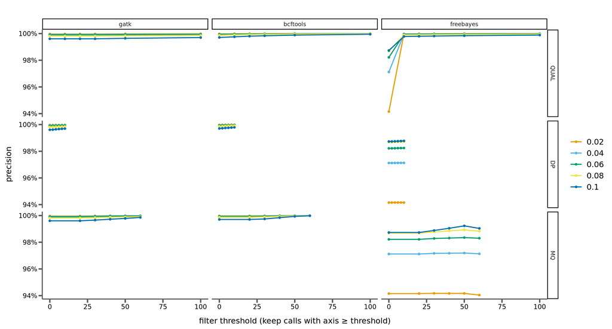

```r
ggplot(df, aes(threshold, precision, color = divergence)) +
  geom_line(linewidth = 0.8) + geom_point(size = 1.2) +
  facet_grid(axis ~ caller, scales = "free_x") +
  scale_color_manual(values = dcols, name = "divergence") +
  scale_y_continuous(labels = scales::percent) +
  labs(x = "filter threshold (keep calls with axis ≥ threshold)", y = "precision") +
  bartheme() + theme(legend.position = "right")
```

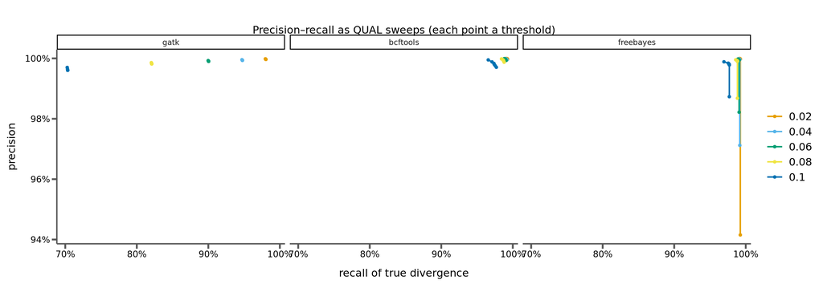

```r
# the classic view: recall vs precision as QUAL sweeps (each point a threshold)
ggplot(df %>% filter(axis == "QUAL"), aes(recall, precision, color = divergence)) +
  geom_path(linewidth = 0.8) + geom_point(size = 1.2) +
  facet_wrap(~caller, nrow = 1) +
  scale_color_manual(values = dcols, name = "divergence") +
  scale_x_continuous(labels = scales::percent) +
  scale_y_continuous(labels = scales::percent) +
  labs(x = "recall of true divergence", y = "precision",
       title = "Precision–recall as QUAL sweeps (each point a threshold)") +
  bartheme() + theme(legend.position = "right")
```